# Campbell

Topics that will be discussed in this summary report for Campbell County are

- Demographic Characteristics
  - Population growth from 1970 to 2020;
  - population density
  - sex, race, and age
  - educational level of the adult population
  - housing characteristics in terms of age of the housing stock and type of tenure
- Economic Characteristics
  - family income, household income, per capita income,
  - poverty status of families;
  - employment classification according to industry;
  - labor force by place of work and commuting patterns;

For more details on the data used, please see the Data Description tab.

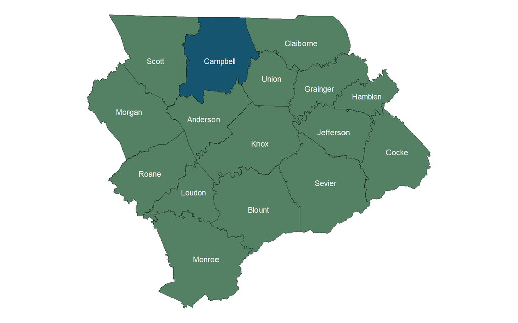

**Population and Growth**

| Place | 1970 | 1980 | 1990 | 2000 | 2010 | 2020 | Change 1970-1980 | Change 1980-1990 | Change 1990-2000 | Change 2000-2010 | Change 2010-2020 |
| --- | --- | --- | --- | --- | --- | --- | --- | --- | --- | --- | --- |
| Campbell County | 26045 | 34923 | 35079 | 39854 | 40716 | 39272 | 8878 | 156 | 4775 | 862 | -1444 |
| Caryville |  | 2039 | 1751 | 2243 | 2297 | 2212 |  | -288 | 492 | 54 | -85 |
| Jacksboro |  | 1722 | 1568 | 1887 | 2020 | 2306 |  | -154 | 319 | 133 | 286 |
| Jellico | 2235 | 2798 | 2447 | 2448 | 2355 | 2154 | 563 | -351 | 1 | -93 | -201 |
| La Follette | 6902 | 8198 | 7192 | 7926 | 7456 | 7430 | 1296 | -1006 | 734 | -470 | -26 |

[interactive chart not shown]

IPUMS NHGIS, University of Minnesota, www.nhgis.org

**Population Density**

| Place | Area | Population Density |
| --- | --- | --- |
| Campbell County | 497.9943309195119 | 78.86033547307052 |
| Caryville | 5.372712794611362 | 411.7100773036958 |
| Jacksboro | 2.580416184722181 | 893.654292533541 |
| Jellico | 6.289665128037548 | 342.4665631876135 |
| La Follette | 4.91322490705977 | 1512.245040792637 |

[interactive chart not shown]

source: U. S. Census Bureau *Decennial Census: Redistricting Data (PL 94-171)*, 2020, accessed June 2, 2026, http://api.census.gov/data/2020/dec/pl.

**Population Descriptions**

| Place | Year | Race Category | Number of People | Percentage of People |
| --- | --- | --- | --- | --- |
| Campbell County | 2020 | Black | 133 | 0.002491849964402143 |
| Campbell County | 2020 | Other | 1872 | 0.03507325664181062 |
| Campbell County | 2020 | White | 37267 | 0.6982238543110878 |
| Caryville | 2020 | Black | 3 | 5.620714205418368e-05 |
| Caryville | 2020 | Other | 105 | 0.001967249971896429 |
| Caryville | 2020 | White | 2104 | 0.03941994229400082 |
| Jacksboro | 2020 | Black | 8 | 0.0001498857121444898 |
| Jacksboro | 2020 | Other | 110 | 0.002060928541986735 |
| Jacksboro | 2020 | White | 2188 | 0.04099374227151797 |
| Jellico | 2020 | Black | 31 | 0.0005808071345598981 |

[output cut: 5 more lines]

| Place | Sex | Age Range | Year | Number of People | Percentage of People |
| --- | --- | --- | --- | --- | --- |
| Campbell County | Female | 10 to 14 years | 2020 | 1068 | 0.01995888618949729 |
| Campbell County | Female | 15 to 19 years | 2020 | 1120 | 0.02093066716501589 |
| Campbell County | Female | 20 to 24 years | 2020 | 1059 | 0.01979069332834984 |
| Campbell County | Female | 25 to 29 years | 2020 | 1263 | 0.02360306484769202 |
| Campbell County | Female | 30 to 34 years | 2020 | 1096 | 0.02048215286862269 |
| Campbell County | Female | 35 to 39 years | 2020 | 1366 | 0.02552793870304616 |
| Campbell County | Female | 40 to 44 years | 2020 | 954 | 0.0178284432816296 |
| Campbell County | Female | 45 to 49 years | 2020 | 1451 | 0.0271164268361054 |
| Campbell County | Female | 5 to 9 years | 2020 | 1028 | 0.0192113623621753 |
| Campbell County | Female | 50 to 54 years | 2020 | 1405 | 0.0262567744346851 |

[output cut: 170 more lines]

[interactive chart not shown]

source: U. S. Census Bureau *Decennial Census: Redistricting Data (PL 94-171)*, 2020, accessed June 2, 2026, http://api.census.gov/data/2020/dec/pl.

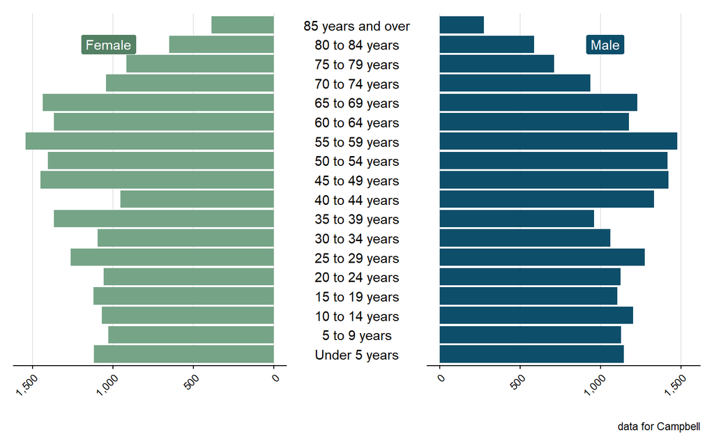

source: U. S. Census Bureau *American Community Survey 5-Year Estimates: Comparison Profiles 5-Year*, 2020, accessed June 2, 2026, http://api.census.gov/data/2020/acs/acs5.

**Education**

| Place | Level of Education | Year | Number of People | Percentage of People |
| --- | --- | --- | --- | --- |
| Campbell County | 9th to 12th Grade, No Diploma | 2010 | 3793 | 0.0991789561761322 |
| Campbell County | Associate's degree | 2010 | 1122 | 0.02933793536240979 |
| Campbell County | Bachelor's degree | 2010 | 1637 | 0.04280409998954084 |
| Campbell County | Graduate or Professional Degree | 2010 | 980 | 0.0256249346302688 |
| Campbell County | Less Than 9th Grade | 2010 | 4375 | 0.1143970295994143 |
| Campbell County | Some College, No Degree | 2010 | 4228 | 0.110553289404874 |
| Campbell County | Total | 2010 | 28486 | 0.7448488651814664 |
| Campbell County | 9th to 12th Grade, No Diploma | 2020 | 2978 | 0.07713027713027713 |
| Campbell County | Associate's degree | 2020 | 1821 | 0.04716394716394717 |
| Campbell County | Bachelor's degree | 2020 | 2315 | 0.05995855995855996 |

[output cut: 60 more lines]

[interactive chart not shown]

source: U. S. Census Bureau *American Community Survey 5-Year Estimates: Comparison Profiles 5-Year*, 2020, accessed June 2, 2026, http://api.census.gov/data/2020/acs/acs5.

**Housing Units by Year of Construction**

| Place | Year | 1939 or earlier | 1940-1959 | 1960-1979 | 1980 to 1989 | 1990 to 1999 | 2000 to 2004 | 2005 or later | 2000 to 2009 | 2010 or later | Total |
| --- | --- | --- | --- | --- | --- | --- | --- | --- | --- | --- | --- |
| Campbell County | 2010 | 1591 | 2617 | 5863 | 2656 | 4174 | 2055 | 698 |  |  | 19654 |
| Campbell County | 2020 | 1177 | 2261 | 6459 | 3084 | 3833 |  |  | 3113 | 1280 | 21207 |
| Caryville | 2010 | 12 | 183 | 283 | 101 | 237 | 123 | 32 |  |  | 971 |
| Jacksboro | 2010 | 0 | 118 | 391 | 232 | 194 | 79 | 33 |  |  | 1047 |
| Jellico | 2010 | 296 | 94 | 342 | 104 | 210 | 73 | 23 |  |  | 1142 |
| La Follette | 2010 | 546 | 922 | 1147 | 355 | 461 | 131 | 93 |  |  | 3655 |
| Caryville | 2020 | 59 | 100 | 402 | 187 | 211 |  |  | 117 | 27 | 1103 |
| Jacksboro | 2020 | 11 | 170 | 520 | 169 | 222 |  |  | 133 | 55 | 1280 |
| Jellico | 2020 | 130 | 178 | 420 | 159 | 224 |  |  | 73 | 4 | 1188 |
| La Follette | 2020 | 414 | 707 | 1195 | 339 | 346 |  |  | 247 | 85 | 3333 |

[interactive chart not shown]

source: U. S. Census Bureau *Decennial Census: Redistricting Data (PL 94-171)*, 2020, accessed June 2, 2026, http://api.census.gov/data/2020/dec/pl.

**Housing Units by Type of Tenure**

| Place | Year | Own | Rent | Total |
| --- | --- | --- | --- | --- |
| Campbell County | 2010 | 11366 | 4425 | 15791 |
| Campbell County | 2020 | 10934 | 5527 | 16461 |
| Caryville | 2010 | 535 | 306 | 841 |
| Jacksboro | 2010 | 592 | 243 | 835 |
| Jellico | 2010 | 687 | 265 | 952 |
| La Follette | 2010 | 1380 | 1749 | 3129 |
| Caryville | 2020 | 659 | 338 | 997 |
| Jacksboro | 2020 | 545 | 493 | 1038 |
| Jellico | 2020 | 445 | 530 | 975 |
| La Follette | 2020 | 1127 | 1693 | 2820 |

[interactive chart not shown]

source: U. S. Census Bureau *Decennial Census: Redistricting Data (PL 94-171)*, 2020, accessed June 2, 2026, http://api.census.gov/data/2020/dec/pl.

**Income Comparison**

| Place | Year | Median Family Income | Median Household Income | Per Capita Income |
| --- | --- | --- | --- | --- |
| Campbell County | 2020 | 51896 | 41769 | 24670 |
| Caryville | 2020 | 54643 | 43657 | 28074 |
| Jacksboro | 2020 | 68594 | 45650 | 24409 |
| Jellico | 2020 | 34800 | 23750 | 20214 |
| La Follette | 2020 | 37861 | 36506 | 21369 |

[interactive chart not shown]

source: U. S. Census Bureau *Decennial Census: Redistricting Data (PL 94-171)*, 2020, accessed June 2, 2026, http://api.census.gov/data/2020/dec/pl.

**Povery Status**

| Place | Year | Above Poverty | Below Poverty |
| --- | --- | --- | --- |
| Campbell County | 2020 | 9324 | 1711 |
| Caryville | 2020 | 527 | 137 |
| Jacksboro | 2020 | 511 | 47 |
| Jellico | 2020 | 435 | 167 |
| La Follette | 2020 | 1282 | 463 |

[interactive chart not shown]

source: U. S. Census Bureau *American Community Survey 5-Year Estimates: Comparison Profiles 5-Year*, 2020, accessed June 2, 2026, http://api.census.gov/data/2020/acs/acs5.

**Poverty Status by Family Type**

| Place | Poverty Status | Family Type | Number of Families | Year | Percentage of Families |
| --- | --- | --- | --- | --- | --- |
| Campbell County | Above Poverty | All Families | 9324 | 2020 | 0.6384552177485621 |
| Campbell County | Above Poverty | Female Householder | 1526 | 2020 | 0.1044919200219118 |
| Campbell County | Above Poverty | Female Householder with related children | 857 | 2020 | 0.05868255272528074 |
| Campbell County | Below Poverty | All Families | 1711 | 2020 | 0.1171596822788277 |
| Campbell County | Below Poverty | Female Householder | 966 | 2020 | 0.06614626129827444 |
| Campbell County | Below Poverty | Female Householder with related children | 839 | 2020 | 0.05745001369487811 |
| Caryville | Above Poverty | All Families | 527 | 2020 | 0.03608600383456587 |
| Caryville | Above Poverty | Female Householder | 84 | 2020 | 0.005751848808545604 |
| Caryville | Above Poverty | Female Householder with related children | 46 | 2020 | 0.003149821966584497 |
| Caryville | Below Poverty | All Families | 137 | 2020 | 0.009380991509175568 |

[output cut: 20 more lines]

[interactive chart not shown]

source: U. S. Census Bureau *American Community Survey 5-Year Estimates: Comparison Profiles 5-Year*, 2020, accessed June 2, 2026, http://api.census.gov/data/2020/acs/acs5.

**Employment by Industry**

| Place | Industry | Year | Number of Jobs | Percentage of Jobs |
| --- | --- | --- | --- | --- |
| Campbell County | Arts, Entertainment, And Recreation, And Accommodation And Food Services | 2010 | 961 | 0.06788640858999717 |
| Campbell County | Arts, Entertainment, And Recreation, And Accommodation And Food Services | 2020 | 1489 | 1.475718533201189 |
| Campbell County | Construction | 2010 | 1597 | 0.1128143543373834 |
| Campbell County | Construction | 2020 | 1999 | 1.981169474727453 |
| Campbell County | Educational Services, And Health Care And Social Assistance | 2010 | 2998 | 0.2117829895450692 |
| Campbell County | Educational Services, And Health Care And Social Assistance | 2020 | 3553 | 3.521308225966303 |
| Campbell County | Manufacturing | 2010 | 2748 | 0.1941226335122916 |
| Campbell County | Manufacturing | 2020 | 2423 | 2.401387512388503 |
| Campbell County | Other Industries | 2010 | 4413 | 0.3117406046905906 |
| Campbell County | Other Industries | 2020 | 4652 | 4.610505450941527 |

[output cut: 50 more lines]

[interactive chart not shown]

source: U. S. Census Bureau *American Community Survey 5-Year Estimates: Comparison Profiles 5-Year*, 2020, accessed June 2, 2026, http://api.census.gov/data/2020/acs/acs5.

**Employment by Industry (Historical)**

| Place | Year | Industry | Number of Jobs | Percentage of Jobs |
| --- | --- | --- | --- | --- |
| Campbell County | 2010 | Agriculture, Forestry, Fishing And Hunting, And Mining | 343 | 0.01824953445065177 |
| Campbell County | 2010 | Construction | 1597 | 0.08496940675711626 |
| Campbell County | 2010 | Manufacturing | 2748 | 0.1462090981644054 |
| Campbell County | 2010 | Other | 707 | 0.03761638733705773 |
| Campbell County | 2010 | Professional Services | 4755 | 0.2529928172386273 |
| Campbell County | 2010 | Public Administration | 592 | 0.03149773876030859 |
| Campbell County | 2010 | Trade, Finance, Insurance &amp; Real Estate | 3414 | 0.1816440542697526 |
| Campbell County | 2020 | Agriculture, Forestry, Fishing And Hunting, And Mining | 279 | 0.01358457493426819 |
| Campbell County | 2020 | Construction | 1999 | 0.09733177524588568 |
| Campbell County | 2020 | Manufacturing | 2423 | 0.1179764339273542 |

[output cut: 60 more lines]

**Labor Force by Place of Work**

| Place | Year | Work Out Of State | Work Out of County of Residence | Work in County of Residence |
| --- | --- | --- | --- | --- |
| Campbell County | 2020 | 786 | 5560 | 9047 |
| Caryville | 2020 | 10 | 309 | 680 |
| Jacksboro | 2020 | 21 | 434 | 516 |
| Jellico | 2020 | 80 | 111 | 345 |
| La Follette | 2020 | 75 | 825 | 1423 |

[interactive chart not shown]

source: U. S. Census Bureau *American Community Survey 5-Year Estimates: Comparison Profiles 5-Year*, 2020, accessed June 2, 2026, http://api.census.gov/data/2020/acs/acs5.

**Commuting Patterns**

| Home County | Year | Number of Jobs | Percentage of Jobs |
| --- | --- | --- | --- |
| Campbell | 2020 | 4619 | 0.305630913782836 |
| Campbell | 2010 | 4534 | 0.3000066168199563 |
| Knox | 2020 | 616 | 0.04075961093098657 |
| Knox | 2010 | 495 | 0.03275325878382849 |
| Anderson | 2020 | 438 | 0.02898167140872097 |
| Anderson | 2010 | 363 | 0.02401905644147423 |
| Blount | 2020 | 84 | 0.00555812876331635 |
| Blount | 2010 | 60 | 0.003970091973797393 |
| Davidson | 2010 | 35 | 0.002315886984715146 |
| Davidson | 2020 | 33 | 0.002183550585588566 |

[output cut: 3 more lines]

| Work County | Year | Number of Jobs | Percentage of Jobs |
| --- | --- | --- | --- |
| Campbell | 2020 | 4619 | 0.305630913782836 |
| Campbell | 2010 | 4534 | 0.3000066168199563 |
| Knox | 2020 | 2902 | 0.1920201151326672 |
| Knox | 2010 | 2737 | 0.1811023622047244 |
| Anderson | 2020 | 2375 | 0.1571494739628135 |
| Anderson | 2010 | 2010 | 0.1329980811222127 |
| Claiborne | 2020 | 261 | 0.01726990008601866 |
| Claiborne | 2010 | 252 | 0.01667438628994905 |
| Scott | 2020 | 191 | 0.01263812611658837 |
| Scott | 2010 | 127 | 0.008403361344537815 |

[output cut: 3 more lines]

[interactive chart not shown]

source: U. S. Census Bureau *Tn_od_main_JT00_2020*, LEHD Origin-Destination Employment Statistics, 8.3, 2020, accessed June 2, 2026, https://lehd.ces.census.gov/data/lodes/.

## References

Bureau, U. S. Census. *American Community Survey 5-Year Estimates: Comparison Profiles 5-Year*. 2020. Accessed June 2, 2026. http://api.census.gov/data/2020/acs/acs5.

Bureau, U. S. Census. *Decennial Census: Redistricting Data (PL 94-171)*. 2020. Accessed June 2, 2026. http://api.census.gov/data/2020/dec/pl.

Bureau, U. S. Census. *Tn_od_main_JT00_2020*. LEHD Origin-Destination Employment Statistics, 8.3. 2020. Accessed June 2, 2026. https://lehd.ces.census.gov/data/lodes/.